# Date-15

Akshay Terode

15 November 2018

## The managing director of a consulting group has the following monthly data on total overhead costs and professional labor hours to bill to clients: 4

1. Develop a trendline to identify the relationship between billable hours and overhead costs.
2. Interpret the coefficients of your regression model. Specifically, what does the fixed component of the model mean to the consulting firm?
3. If a special job requiring 1,000 billable hours that would contribute a margin of $38,000 before overhead was available, would the job be attractive?

```r
overheads <- c(365,400,430,477,560,587)*1000
billable <- c(3,4,5,6,7,8)*1000
cor(overheads,billable)
```

```
## [1] 0.9861807
```

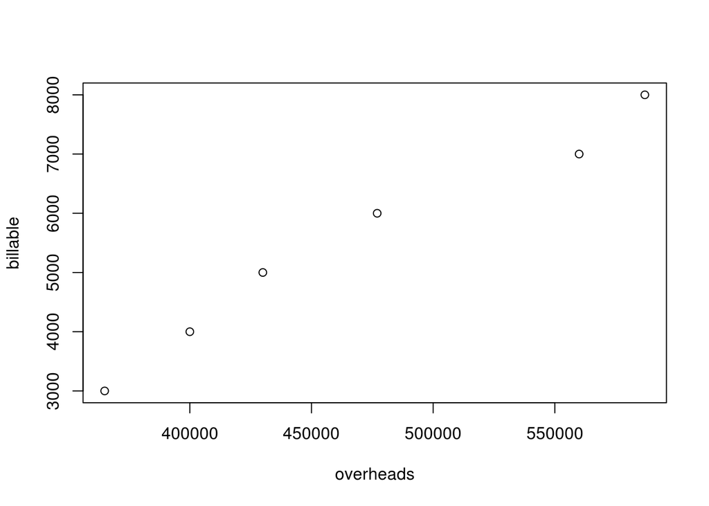

```r
plot(overheads,billable)
```

```r
fitLm <- lm(overheads ~ billable)
fitLm
```

```
##
## Call:
## lm(formula = overheads ~ billable)
##
## Coefficients:
## (Intercept)     billable
##   212590.48        46.77
```

## Regresssion Equation

overheads = b0+b1 billable  
overheads = 212590.48 + 46.77 billable

```r
#c
212590.48 + 46.77*1000
```

```
## [1] 259360.5
```

```r
#Consider medv as response
library(MASS)
data("Boston")
lm2 <- lm(medv ~ .,data = Boston)
lm2
```

```
##
## Call:
## lm(formula = medv ~ ., data = Boston)
##
## Coefficients:
## (Intercept)         crim           zn        indus         chas
##   3.646e+01   -1.080e-01    4.642e-02    2.056e-02    2.687e+00
##         nox           rm          age          dis          rad
##  -1.777e+01    3.810e+00    6.922e-04   -1.476e+00    3.060e-01
##         tax      ptratio        black        lstat
##  -1.233e-02   -9.527e-01    9.312e-03   -5.248e-01
```

```r
summary(lm2)
```

```
##
## Call:
## lm(formula = medv ~ ., data = Boston)
##
## Residuals:
##     Min      1Q  Median      3Q     Max
## -15.595  -2.730  -0.518   1.777  26.199
##
## Coefficients:
##               Estimate Std. Error t value Pr(>|t|)
## (Intercept)  3.646e+01  5.103e+00   7.144 3.28e-12 ***
## crim        -1.080e-01  3.286e-02  -3.287 0.001087 **
## zn           4.642e-02  1.373e-02   3.382 0.000778 ***
## indus        2.056e-02  6.150e-02   0.334 0.738288
## chas         2.687e+00  8.616e-01   3.118 0.001925 **
## nox         -1.777e+01  3.820e+00  -4.651 4.25e-06 ***
## rm           3.810e+00  4.179e-01   9.116  < 2e-16 ***
## age          6.922e-04  1.321e-02   0.052 0.958229
## dis         -1.476e+00  1.995e-01  -7.398 6.01e-13 ***
## rad          3.060e-01  6.635e-02   4.613 5.07e-06 ***
## tax         -1.233e-02  3.760e-03  -3.280 0.001112 **
## ptratio     -9.527e-01  1.308e-01  -7.283 1.31e-12 ***
## black        9.312e-03  2.686e-03   3.467 0.000573 ***
## lstat       -5.248e-01  5.072e-02 -10.347  < 2e-16 ***
## ---
## Signif. codes:  0 '***' 0.001 '**' 0.01 '*' 0.05 '.' 0.1 ' ' 1
##
## Residual standard error: 4.745 on 492 degrees of freedom
## Multiple R-squared:  0.7406, Adjusted R-squared:  0.7338
## F-statistic: 108.1 on 13 and 492 DF,  p-value: < 2.2e-16
```

### Observation :

p-value of ANOVA : 2.2 * 10^-16 Hence the model is valid.

```r
library(AppliedPredictiveModeling)
data(concrete)
head(concrete)
```

```
##   Cement BlastFurnaceSlag FlyAsh Water Superplasticizer CoarseAggregate
## 1  540.0              0.0      0   162              2.5          1040.0
## 2  540.0              0.0      0   162              2.5          1055.0
## 3  332.5            142.5      0   228              0.0           932.0
## 4  332.5            142.5      0   228              0.0           932.0
## 5  198.6            132.4      0   192              0.0           978.4
## 6  266.0            114.0      0   228              0.0           932.0
##   FineAggregate Age CompressiveStrength
## 1         676.0  28               79.99
## 2         676.0  28               61.89
## 3         594.0 270               40.27
## 4         594.0 365               41.05
## 5         825.5 360               44.30
## 6         670.0  90               47.03
```

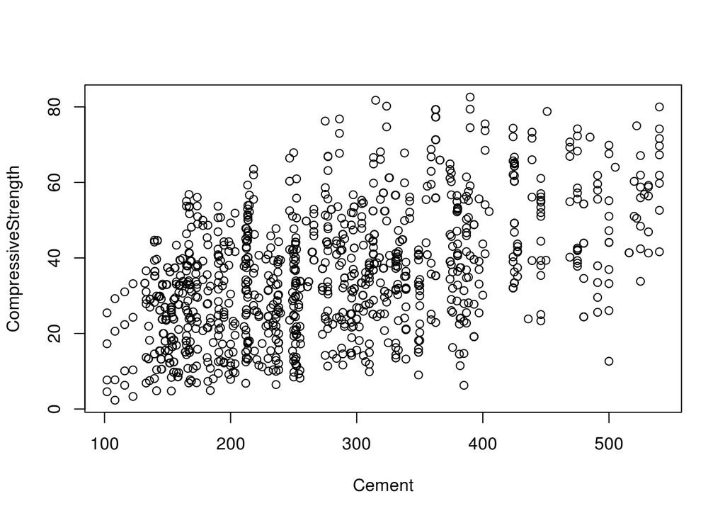

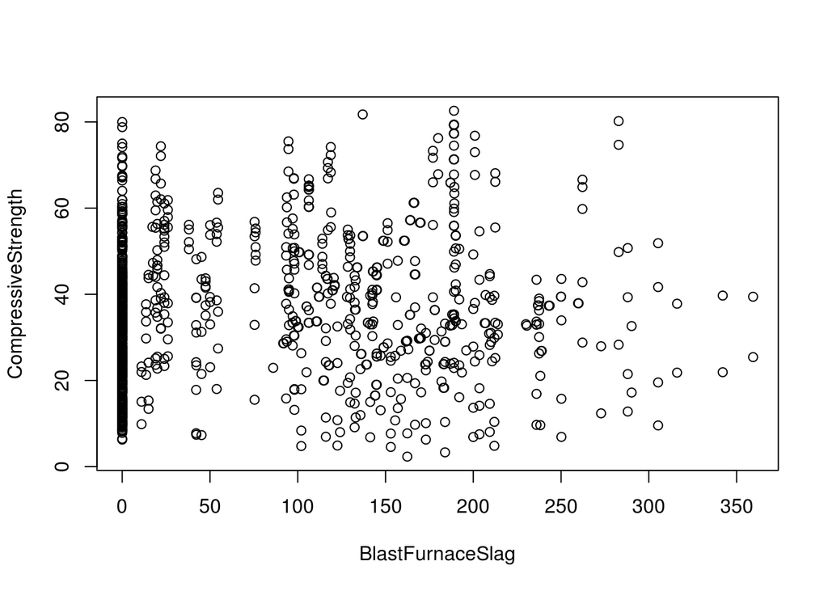

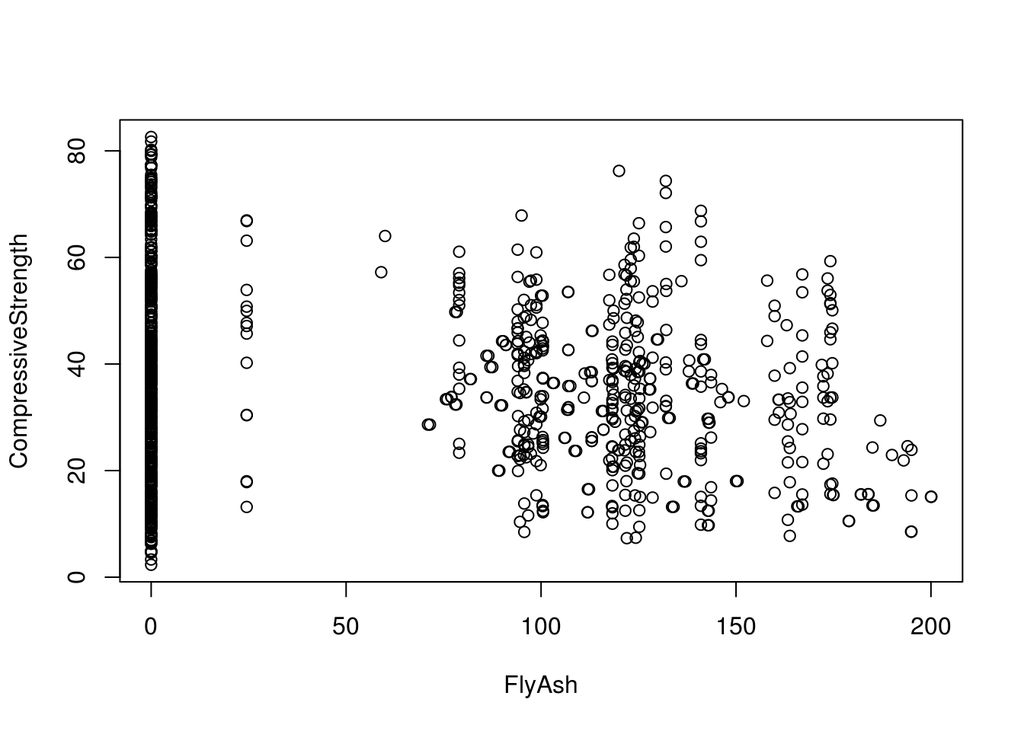

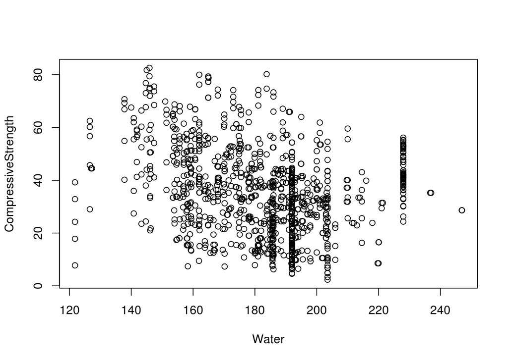

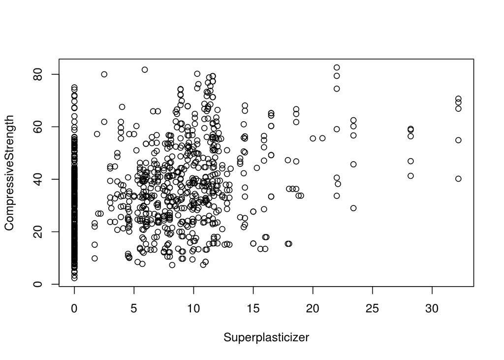

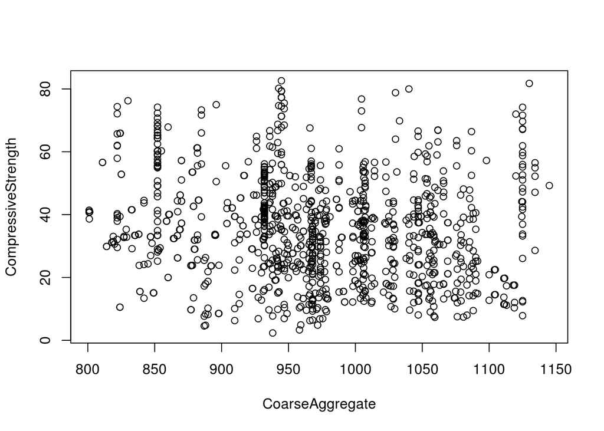

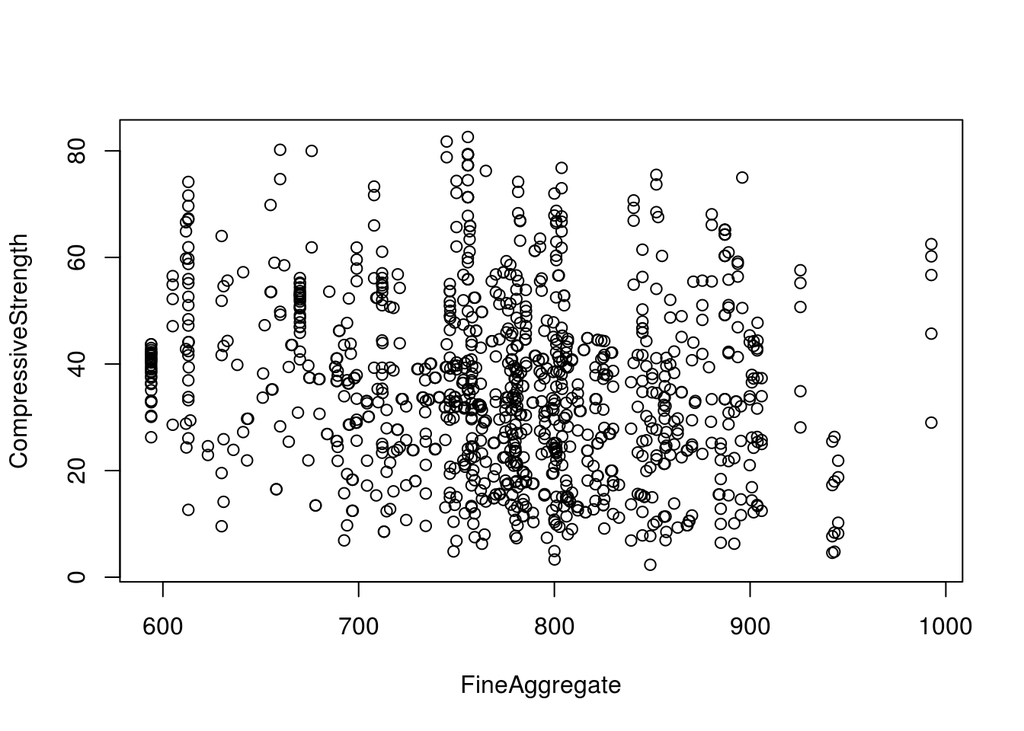

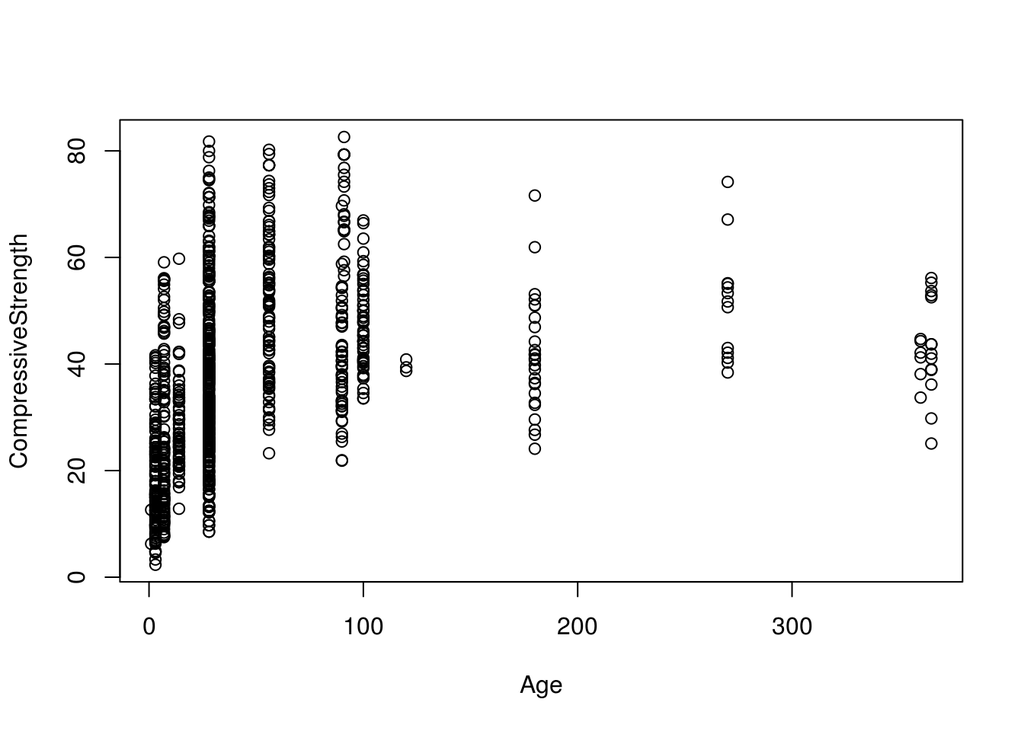

```r
lm3 <- lm(CompressiveStrength ~.,data = concrete)
plot(CompressiveStrength ~.,data = concrete)
```

```r
lm3
```

```
##
## Call:
## lm(formula = CompressiveStrength ~ ., data = concrete)
##
## Coefficients:
##      (Intercept)            Cement  BlastFurnaceSlag            FlyAsh
##        -23.33121           0.11980           0.10387           0.08793
##            Water  Superplasticizer   CoarseAggregate     FineAggregate
##         -0.14992           0.29222           0.01809           0.02019
##              Age
##          0.11422
```

```r
summary(lm3)
```

```
##
## Call:
## lm(formula = CompressiveStrength ~ ., data = concrete)
##
## Residuals:
##     Min      1Q  Median      3Q     Max
## -28.654  -6.302   0.703   6.569  34.450
##
## Coefficients:
##                    Estimate Std. Error t value Pr(>|t|)
## (Intercept)      -23.331214  26.585504  -0.878 0.380372
## Cement             0.119804   0.008489  14.113  < 2e-16 ***
## BlastFurnaceSlag   0.103866   0.010136  10.247  < 2e-16 ***
## FlyAsh             0.087934   0.012583   6.988 5.02e-12 ***
## Water             -0.149918   0.040177  -3.731 0.000201 ***
## Superplasticizer   0.292225   0.093424   3.128 0.001810 **
## CoarseAggregate    0.018086   0.009392   1.926 0.054425 .
## FineAggregate      0.020190   0.010702   1.887 0.059491 .
## Age                0.114222   0.005427  21.046  < 2e-16 ***
## ---
## Signif. codes:  0 '***' 0.001 '**' 0.01 '*' 0.05 '.' 0.1 ' ' 1
##
## Residual standard error: 10.4 on 1021 degrees of freedom
## Multiple R-squared:  0.6155, Adjusted R-squared:  0.6125
## F-statistic: 204.3 on 8 and 1021 DF,  p-value: < 2.2e-16
```

## Q16 -

#### Using the data in the Excel file Credit Card Spending, develop a multiple linear regression model for estimating the average credit card expenditure as a function of both the income and family size. Predict the average expense of a family that has two members and an income of $188,000 per annum, and another that has three members and an income of $39,000 income per annum.

```r
library(readxl)
cds <- read_xlsx("/home/student/RCodes/Stats With R/Data_Files/Credit Card Spending.xlsx",range = "A3:C52")
lm4 <- lm(CC_Exp ~.,data = cds)
lm4
```

```
##
## Call:
## lm(formula = CC_Exp ~ ., data = cds)
##
## Coefficients:
## (Intercept)       Income   FamilySize
##     0.90737      0.02523     -0.31062
```

```r
summary(lm4)
```

```
##
## Call:
## lm(formula = CC_Exp ~ ., data = cds)
##
## Residuals:
##     Min      1Q  Median      3Q     Max
## -4.3598 -0.8518 -0.2072  0.6715  3.7616
##
## Coefficients:
##              Estimate Std. Error t value Pr(>|t|)
## (Intercept)  0.907367   0.565355   1.605   0.1153
## Income       0.025232   0.004297   5.871 4.51e-07 ***
## FamilySize  -0.310622   0.165832  -1.873   0.0674 .
## ---
## Signif. codes:  0 '***' 0.001 '**' 0.01 '*' 0.05 '.' 0.1 ' ' 1
##
## Residual standard error: 1.427 on 46 degrees of freedom
## Multiple R-squared:  0.4557, Adjusted R-squared:  0.432
## F-statistic: 19.25 on 2 and 46 DF,  p-value: 8.412e-07
```

## Linear Regression Equation

0.907367 + 0.025232 * Income - 0.310622 * FamilySize

```
## [1] "The average expense of family having 2 members and an income of $188,000 per annum is -> 5.029739"
```

```
## [1] "The average expense of family having 3 members and an income of $39,000 per annum is -> 0.959549"
```

### Assumptions Of Regression

- Normality : Errors are Normally Distribuited with mean zero.
- Independence : Errors are independent.
- Linearity : Mean of dependent variable Y is linearly related to Xis.
- Homoscedasticity : Errors have constant variance.

### Q18:Pg 296

#### The Excel file Salary Data provides information on current salary, beginning salary, previous experience (in months) when hired, and total years of education for a sample of 100 employees in a firm.

- 1. Develop a multiple regression model for predicting current salary as a function of the other variables.
- 2. Find the best model for predicting current salary using the t-value criterion.

```r
library(readxl)
sal <- read_xlsx("/home/student/RCodes/Stats With R/Data_Files/Salary Data.xlsx",range = "A3:D103")
fitlm.2 <- lm(`Current Salary` ~ ., data = sal)
fitlm.2
```

```
##
## Call:
## lm(formula = `Current Salary` ~ ., data = sal)
##
## Coefficients:
##                    (Intercept)              `Beginning Salary`
##                       -4139.24                            1.73
## `Previous Experience (months)`             `Education (years)`
##                         -10.91                          719.12
```

```r
summary(fitlm.2)
```

```
##
## Call:
## lm(formula = `Current Salary` ~ ., data = sal)
##
## Residuals:
##    Min     1Q Median     3Q    Max
## -21900  -3583   -577   1418  49548
##
## Coefficients:
##                                  Estimate Std. Error t value Pr(>|t|)
## (Intercept)                    -4139.2377  4203.3582  -0.985   0.3272
## `Beginning Salary`                 1.7302     0.1138  15.203   <2e-16 ***
## `Previous Experience (months)`   -10.9071     7.7710  -1.404   0.1637
## `Education (years)`              719.1221   351.7339   2.045   0.0436 *
## ---
## Signif. codes:  0 '***' 0.001 '**' 0.01 '*' 0.05 '.' 0.1 ' ' 1
##
## Residual standard error: 7791 on 96 degrees of freedom
## Multiple R-squared:  0.8031, Adjusted R-squared:  0.7969
## F-statistic: 130.5 on 3 and 96 DF,  p-value: < 2.2e-16
```

```r
fitlm.3 <- lm(`Current Salary` ~. - `Previous Experience (months)`,data = sal)
fitlm.3
```

```
##
## Call:
## lm(formula = `Current Salary` ~ . - `Previous Experience (months)`,
##     data = sal)
##
## Coefficients:
##         (Intercept)   `Beginning Salary`  `Education (years)`
##            -6276.57                 1.69               852.91
```

```r
summary(fitlm.3)
```

```
##
## Call:
## lm(formula = `Current Salary` ~ . - `Previous Experience (months)`,
##     data = sal)
##
## Residuals:
##    Min     1Q Median     3Q    Max
## -21649  -3536   -825   1553  49876
##
## Coefficients:
##                       Estimate Std. Error t value Pr(>|t|)
## (Intercept)         -6276.5696  3937.3677  -1.594   0.1142
## `Beginning Salary`      1.6904     0.1108  15.261   <2e-16 ***
## `Education (years)`   852.9109   340.2605   2.507   0.0139 *
## ---
## Signif. codes:  0 '***' 0.001 '**' 0.01 '*' 0.05 '.' 0.1 ' ' 1
##
## Residual standard error: 7830 on 97 degrees of freedom
## Multiple R-squared:  0.7991, Adjusted R-squared:  0.7949
## F-statistic: 192.9 on 2 and 97 DF,  p-value: < 2.2e-16
```

#### Conclusion

- H0 : beta1 = 0 ()

## H1 : beta1 != 0 (REJECT)

- H0 : beta2 = 0 (REJECT)

## H1 : beta2 != 0 ()

- H0 : beta3 = 0 ()

## H1 : beta3 != 0 (REJECT)

- H0 : beta4 = 0 (REJECT)
- H1 : beta4 != 0 ()

### Q20

##### Using the data in the Excel file Freshman CollegeData, identify the best regression model for predicting the first year retention rate. For the model you select, conduct further analysis to check for significance of the independent variables and for multicollinearity.

```r
library(readxl)
df <- read_xlsx("/home/student/RCodes/Stats With R/Data_Files/Freshman College Data.xlsx",range = "A3:H47")
lmfit <- lm(`1st year retention rate` ~.,data = df)
summary(lmfit)
```

```
##
## Call:
## lm(formula = `1st year retention rate` ~ ., data = df)
##
## Residuals:
##       Min        1Q    Median        3Q       Max
## -0.125550 -0.020706  0.003919  0.023074  0.082643
##
## Coefficients:
##                                      Estimate Std. Error t value Pr(>|t|)
## (Intercept)                        -2.555e+01  1.336e+01  -1.912   0.0665
## CollegeBusiness                    -6.208e-02  9.311e-02  -0.667   0.5106
## CollegeEducation                   -3.523e-02  1.268e-01  -0.278   0.7833
## CollegeEngineering                 -8.230e-02  3.713e-02  -2.216   0.0353
## CollegeHealth Sciences             -5.683e-02  1.299e-01  -0.438   0.6652
## CollegeLiberal Arts                -7.932e-02  1.032e-01  -0.769   0.4486
## CollegeMusic                       -1.924e-02  5.362e-02  -0.359   0.7225
## CollegeNorth Central Branch Campus -2.594e-02  1.573e-01  -0.165   0.8702
## CollegeNursing                     -1.555e-02  1.174e-01  -0.133   0.8956
## CollegeSouth Central Branch Campus -3.800e-02  1.509e-01  -0.252   0.8032
## CollegeVocational Technology       -3.139e-02  1.250e-01  -0.251   0.8036
## Year                                1.264e-02  6.687e-03   1.891   0.0694
## `Avg ACT`                           2.721e-02  2.907e-02   0.936   0.3577
## `Avg SAT`                           1.536e-04  6.114e-04   0.251   0.8036
## `HS GPA`                            6.363e-02  1.678e-01   0.379   0.7075
## `% top 10%`                         8.035e-02  3.253e-01   0.247   0.8068
## `% top 20%`                        -1.700e-01  2.549e-01  -0.667   0.5104
##
## (Intercept)                        .
## CollegeBusiness
## CollegeEducation
## CollegeEngineering                 *
## CollegeHealth Sciences
## CollegeLiberal Arts
## CollegeMusic
## CollegeNorth Central Branch Campus
## CollegeNursing
## CollegeSouth Central Branch Campus
## CollegeVocational Technology
## Year                               .
## `Avg ACT`
## `Avg SAT`
## `HS GPA`
## `% top 10%`
## `% top 20%`
## ---
## Signif. codes:  0 '***' 0.001 '**' 0.01 '*' 0.05 '.' 0.1 ' ' 1
##
## Residual standard error: 0.04817 on 27 degrees of freedom
## Multiple R-squared:  0.8248, Adjusted R-squared:  0.721
## F-statistic: 7.944 on 16 and 27 DF,  p-value: 1.687e-06
```

### Plotting a pair plot

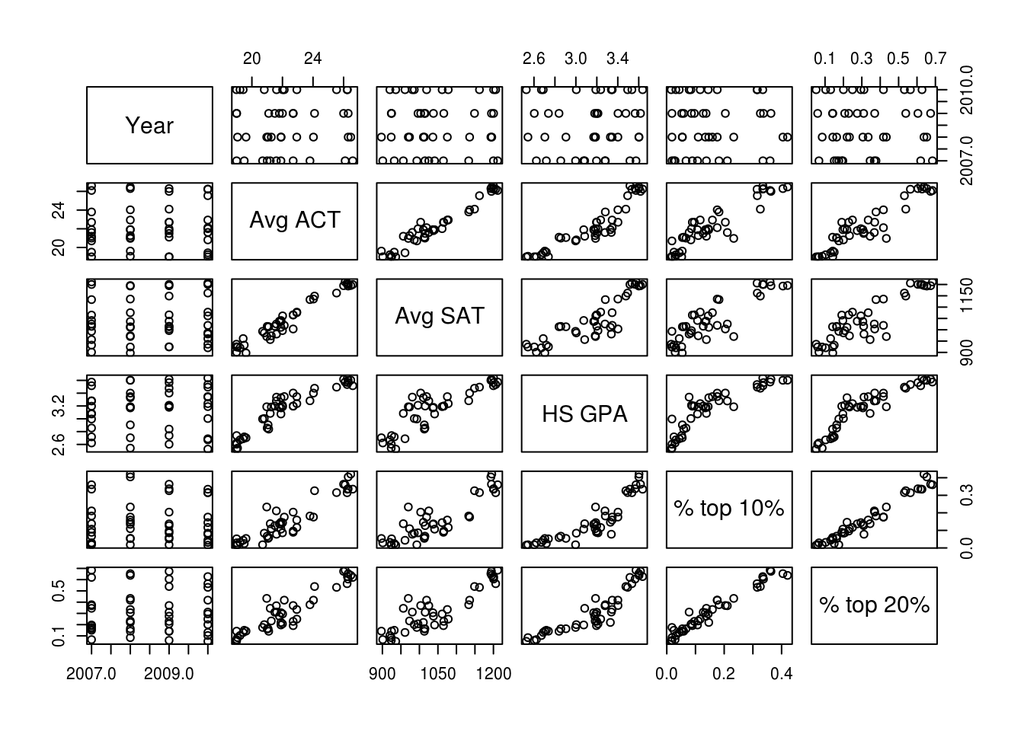

```r
pairs(df[,-c(1,8)])
```

#### Check for multicolinearity

```r
fit.lm <- lm(`1st year retention rate` ~ Year + `Avg ACT`,data = df)
summary(fit.lm)
```

```
##
## Call:
## lm(formula = `1st year retention rate` ~ Year + `Avg ACT`, data = df)
##
## Residuals:
##       Min        1Q    Median        3Q       Max
## -0.158086 -0.022850 -0.004363  0.031782  0.080601
##
## Coefficients:
##               Estimate Std. Error t value Pr(>|t|)
## (Intercept) -26.485771  12.712336  -2.083   0.0435 *
## Year          0.013196   0.006330   2.085   0.0434 *
## `Avg ACT`     0.031986   0.002968  10.779 1.55e-13 ***
## ---
## Signif. codes:  0 '***' 0.001 '**' 0.01 '*' 0.05 '.' 0.1 ' ' 1
##
## Residual standard error: 0.04694 on 41 degrees of freedom
## Multiple R-squared:  0.7474, Adjusted R-squared:  0.735
## F-statistic: 60.65 on 2 and 41 DF,  p-value: 5.636e-13
```